# Unit 2 - Project Management: How to set up a Research Project

James Flynn

August 31, 2026

## Writing a research paper is a massive undertaking

- Come up with idea
- Read relevant literature
- Find appropriate data source to answer question
- Perform analysis
- Test results (robustness)
- Write paper
- Edit paper
- Present paper
- Submit paper (desk-reject)
- Submit paper (reject with reviews)
- Submit paper (R&R!!!)

Still not done…

## What happends when you submit a paper?

- First, your paper goes to the editor
- They read it and decide:
  - Desk-reject the paper (usually happens quick)
  - Send to referees

## It went to referees! What now…

- Usually at least two (I’ve had up to five)
- Each referee will read the paper and:
  - Write a `referee report`
  - Make a recommendation (reject, R&R)
- Editor then makes a decision
  - Reject
  - Revise and Resubmit (R&R)
  - Occasionally, reject and resubmit

## If you get an R&R

- Celebrate!!!
- But then there is work to do
- Average top-five pub has three rounds of revision
- Mean T5 submit-to-accept time is 26 months!*
- Much shorter at field journals, but still takes a while

*Hadavand et al (2021)

## The point is, organization is *crucial*

- Many journals require replication packages
- Need to keep track of
  - Raw data
  - Cleaned data
  - Code
  - Graphs
  - Tables
  - Drafts of paper
- This is all true for public/private sector as well

## Best way to keep track is with a project folder

[figure not shown]

## Then we can create sub-folders

[figure not shown]

## Project setup

[figure not shown]

## Now let’s get some data into RStudio

- Download **imdb250.rds** from Canvas
- Move to your data folder

## Set Working Directory and load data

## Data storage

[figure not shown]

## Loading data in R

[figure not shown]

- Make sure you’re using forward slashes (/)

## Project Management Tips

1: comment, Comment, COMMENT your code

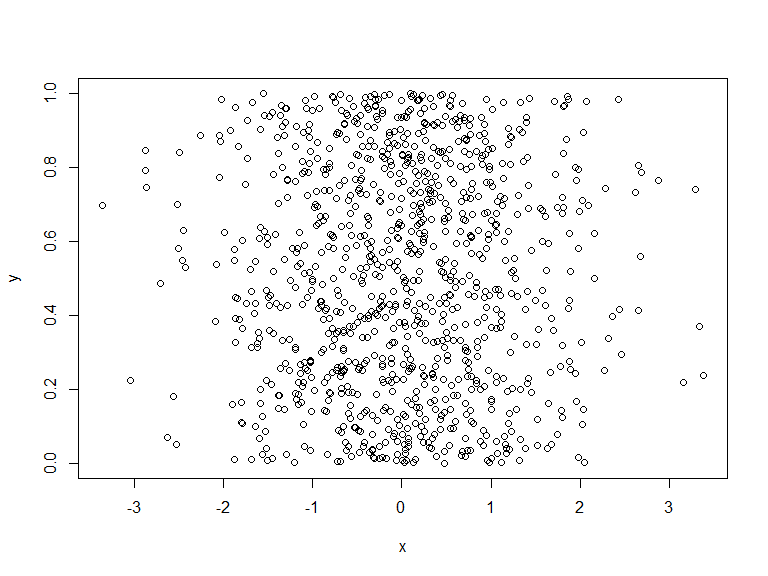

```r
#this line creates a normal random variable
x <- rnorm(1000)
#this line creates a uniform random variable
y <- runif(1000)
#this line gives a scatterplot of x and y
plot(x,y)
```

## 2 - Indent your code when it goes for multiple lines

- This will be especially common in tidyverse

```r
#load mort_2021 data
load("mort_21.RData")

#create new variable for women
mort_2021 <- mort_2021 %>%
  mutate(female = ifelse(sex == "F", 1, 0))
```

## 2 - Indent your code (cont’d)

- Otherwise it can look like this:

```r
mort_2021 %>% mutate(female = ifelse(sex == "F", 1, 0),
married = marstat == "M", autopsy_performed = autopsy == "Y",
years_ed = as.numeric(ifelse(educ2003==1,8, ifelse(educ2003==2,10,
ifelse(educ2003==3,12, ifelse(educ2003==4,13, ifelse(educ2003==5,14,
ifelse(educ2003==6,16, ifelse(educ2003==7,18, ifelse(educ2003==8,21,NA))))))))),
age_years = as.numeric(ifelse(age==1999,NA, ifelse(age<2000,age-1000,0))),) %>%
filter(years_ed!="NA") %>% group_by(female) %>%  summarise(mean_ed = mean(years_ed), mean_age = mean(age))
```

```
## # A tibble: 2 × 3
##   female mean_ed mean_age
##    <dbl>   <dbl>    <dbl>
## 1      0    12.7    1084.
## 2      1    12.5    1089.
```

## 2 - Compare that to this

```r
mort_2021 %>%
  mutate(female = ifelse(sex == "F", 1, 0),
         married = marstat == "M",
         autopsy_performed = autopsy == "Y",
         years_ed = as.numeric(ifelse(educ2003==1,8,
                               ifelse(educ2003==2,10,
                               ifelse(educ2003==3,12,
                               ifelse(educ2003==4,13,
                               ifelse(educ2003==5,14,
                               ifelse(educ2003==6,16,
                               ifelse(educ2003==7,18,
                               ifelse(educ2003==8,21,NA))))))))),
         age_years = as.numeric(ifelse(age==1999,NA,
                                ifelse(age<2000,age-1000,0))),) %>%
  filter(years_ed!="NA") %>%
  group_by(female) %>%
  summarise(mean_ed = mean(years_ed), mean_age = mean(age_years))
```

```
## # A tibble: 2 × 3
##   female mean_ed mean_age
##    <dbl>   <dbl>    <dbl>
## 1      0    12.7     69.3
## 2      1    12.5     75.4
```

## 3 - Aim for efficiency, but don’t become obsessed

- Often times, you can take what you’ve done in 10 lines, and do it all in one or two
- This is very helpful for someone reading your code
- However, if your code gets the job done, don’t waste hours trying to improve it